# Data _ Analysis final ne

##### 25/04/2026 Day(6)

```python
import pandas as pd
```

```python
df=pd.read_csv("Cleaned_Weather.csv")
```

```python
df.columns
```

```
Index(['country', 'location', 'latitude', 'longitude', 'timezone',
       'last_updated', 'temperature_celsius', 'condition_text', 'wind_kph',
       'wind_degree', 'wind_direction', 'pressure_mb', 'precip_mm', 'humidity',
       'cloud', 'feels_like_celsius', 'visibility_km', 'uv_index', 'gust_kph',
       'co', 'ozone', 'no2', 'so2', 'pm2.5', 'pm10',
       'air_quality_us-epa-index', 'air_quality_gb-defra-index', 'sunset',
       'moonrise', 'moonset', 'moon_phase', 'moon_illumination', 'date',
       'time', 'continent', 'city', 'year', 'month', 'hour'],
      dtype='object')
```

# DATA VISUALISATION

### Global Temperature Distribution

```python
import matplotlib.pyplot as plt
import seaborn as sns
```

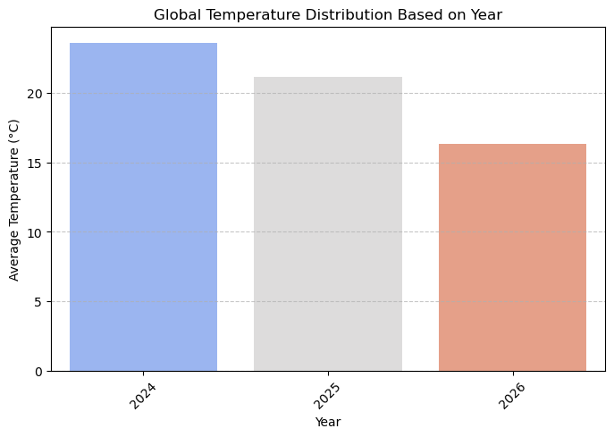

```python
df['date'] = pd.to_datetime(df['date'])
year_temp = df.groupby('year')['temperature_celsius'].mean().reset_index()
plt.figure(figsize=(8,5))
sns.barplot(x='year', y='temperature_celsius', data=year_temp, palette='coolwarm')

plt.title("Global Temperature Distribution Based on Year")
plt.xlabel("Year")
plt.ylabel("Average Temperature (°C)")
plt.xticks(rotation=45)
plt.grid(axis='y', linestyle='--', alpha=0.7)
plt.show()
```

##### This bar chart shows the global average temperature distribution based on year. It helps compare yearly temperature changes and identify warming or cooling trends over time. Higher bars indicate higher average temperatures for that year.

# Temperatures vs Humidity

```python
gf=df.loc[:10]
```

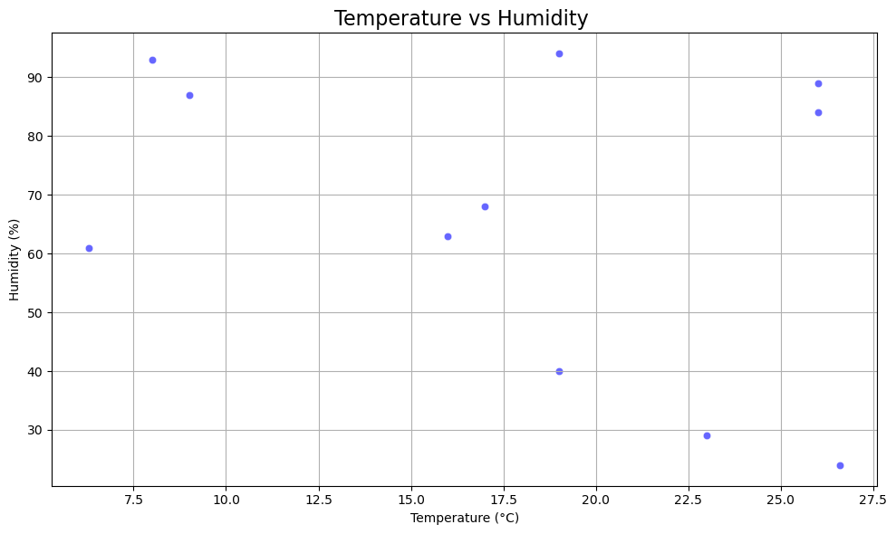

```python
plt.figure(figsize=(10,6))
sns.scatterplot(data=gf,
                x='temperature_celsius',
                y='humidity',
                color='blue',
                alpha=0.6)

plt.title("Temperature vs Humidity ", fontsize=16)
plt.xlabel("Temperature (°C)")
plt.ylabel("Humidity (%)")
plt.grid(True)
plt.tight_layout()
plt.show()
```

#### .Shows relationship between temperature and humidity

Points indicate how humidity changes with temperature.

Scattered pattern → weak or moderate relationship

### Average Global Level (PM 2.5,PM 10)

```python
yearly_pm = df.groupby('year')[['air_quality_PM2.5', 'air_quality_PM10']].mean()
plt.figure(figsize=(12,6))

plt.plot(yearly_pm.index, yearly_pm['air_quality_PM2.5'],
         marker='o', linewidth=2, label='PM2.5')

plt.plot(yearly_pm.index, yearly_pm['air_quality_PM10'],
         marker='s', linewidth=2, label='PM10')

plt.title("Average Global Pollution Level (PM2.5 & PM10) Based on Year")
plt.xlabel("Year")
plt.ylabel("Average Pollution Level")
plt.legend()
plt.grid(True, linestyle='--', alpha=0.7)
plt.show()
```

[output not shown]

[output not shown]

# Top 10 Most Polluted Countries

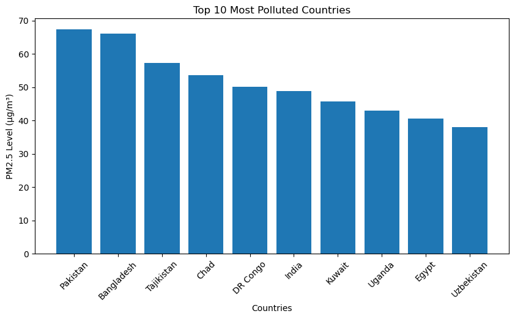

```python
countries = ['Pakistan', 'Bangladesh', 'Tajikistan', 'Chad', 'DR Congo',
             'India', 'Kuwait', 'Uganda', 'Egypt', 'Uzbekistan']
pm25 = [67.3, 66.1, 57.3, 53.6, 50.2, 48.9, 45.7, 43.0, 40.6, 38.1]
plt.figure(figsize=(10,5))
plt.bar(countries, pm25)
plt.xlabel('Countries')
plt.ylabel('PM2.5 Level (µg/m³)')
plt.title('Top 10 Most Polluted Countries')
plt.xticks(rotation=45)
plt.show()
```

#### Compares PM2.5 pollution levels across 10 countries

Higher bars = more air pollution

Helps identify most polluted countries easily

### Global Air Pollution Trend

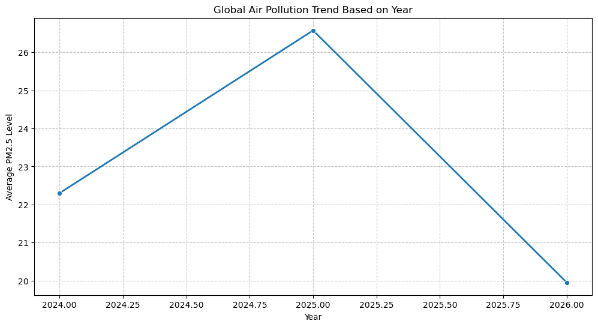

```python
year_pollution = df.groupby('year')['air_quality_PM2.5'].mean().reset_index()
plt.figure(figsize=(12,6))
sns.lineplot(x='year', y='air_quality_PM2.5', data=year_pollution, marker='o', linewidth=2)
plt.title("Global Air Pollution Trend Based on Year")
plt.xlabel("Year")
plt.ylabel("Average PM2.5 Level")
plt.grid(True, linestyle='--', alpha=0.7)
plt.show()
```

##### This chart shows yearly global air pollution trends using average PM2.5 levels. Higher values indicate more pollution.

# Weather Conditions

##### This pie chart shows the global distribution of weather conditions. It compares the percentage of different weather types across the dataset.

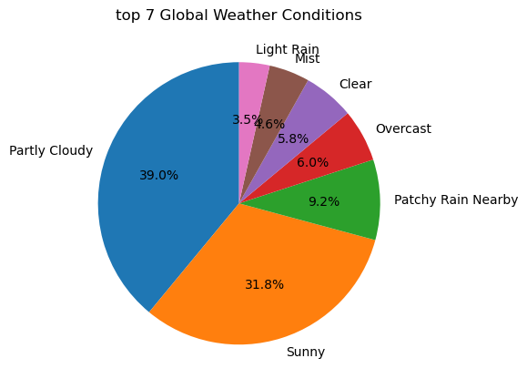

```python
condition_count = df['condition_text'].value_counts().head(7)

plt.figure(figsize=(5,8))
plt.pie(condition_count.values,
        labels=condition_count.index,
        autopct='%1.1f%%',
        startangle=90)

plt.title('top 7 Global Weather Conditions')
plt.show()
```

## High Temperature of Top 10 Countries

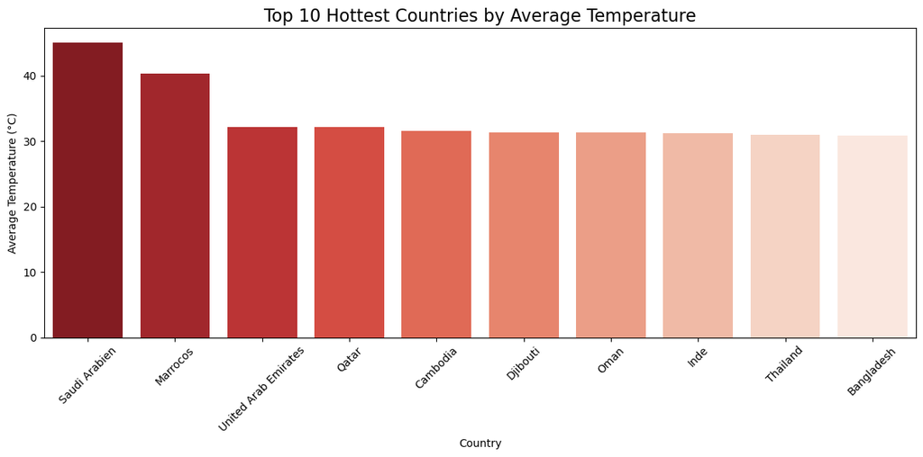

```python
top10_countries = df.groupby('country')['temperature_celsius'].mean().nlargest(10).reset_index()

plt.figure(figsize=(12,6))

sns.barplot(data=top10_countries,
            x='country',
            y='temperature_celsius',
            palette='Reds_r')

plt.title("Top 10 Hottest Countries by Average Temperature", fontsize=16)
plt.xlabel("Country")
plt.ylabel("Average Temperature (°C)")
plt.xticks(rotation=45)
plt.tight_layout()
plt.show()
```

##### This chart shows the top 10 countries with the highest average temperatures. It helps compare the hottest countries in the dataset.

## Humidity by Top 10 Countries

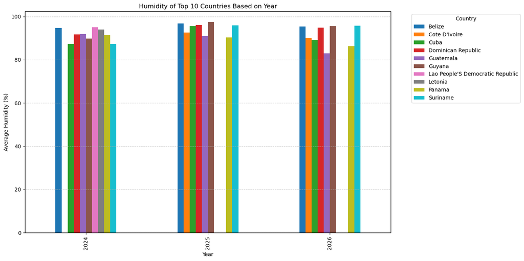

```python
top10_countries = df.groupby('country')['humidity'].mean().sort_values(ascending=False).head(10).index
filtered_df = df[df['country'].isin(top10_countries)]
yearly_humidity = filtered_df.groupby(['year', 'country'])['humidity'].mean().unstack()
yearly_humidity.plot(kind='bar', figsize=(14,7))

plt.title("Humidity of Top 10 Countries Based on Year")
plt.xlabel("Year")
plt.ylabel("Average Humidity (%)")
plt.legend(title="Country", bbox_to_anchor=(1.05, 1), loc='upper left')
plt.grid(axis='y', linestyle='--', alpha=0.7)
plt.tight_layout()
plt.show()
```

##### This chart shows yearly average humidity trends for the top 10 most humid countries. It helps compare humidity changes across years.

# Year_Wise Humidity

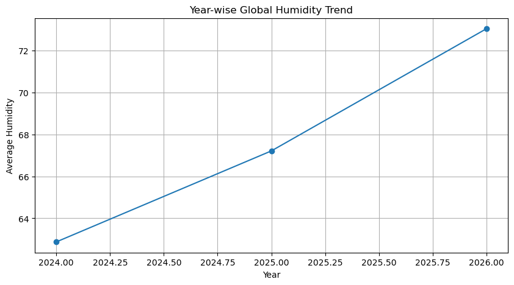

```python
yearly_humidity = df.groupby('year')['humidity'].mean()

plt.figure(figsize=(10,5))
plt.plot(yearly_humidity.index, yearly_humidity.values, marker='o')
plt.title('Year-wise Global Humidity Trend')
plt.xlabel('Year')
plt.ylabel('Average Humidity')
plt.grid(True)
plt.show()
```

# High Temperature by Continent

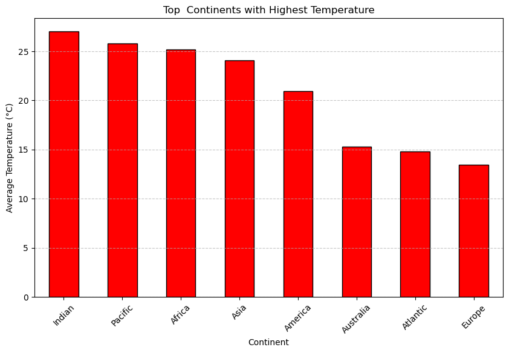

```python
top_continents = df.groupby('continent')['temperature_celsius'].mean().sort_values(ascending=False).head(10)
plt.figure(figsize=(10,6))
top_continents.plot(kind='bar', color='red', edgecolor='black')
plt.title("Top  Continents with Highest Temperature")
plt.xlabel("Continent")
plt.ylabel("Average Temperature (°C)")
plt.xticks(rotation=45)
plt.grid(axis='y', linestyle='--', alpha=0.7)
plt.show()
```

##### This chart shows the continents with the highest average temperatures. It helps compare temperature levels across different continents.

## Temperature Distribution In India

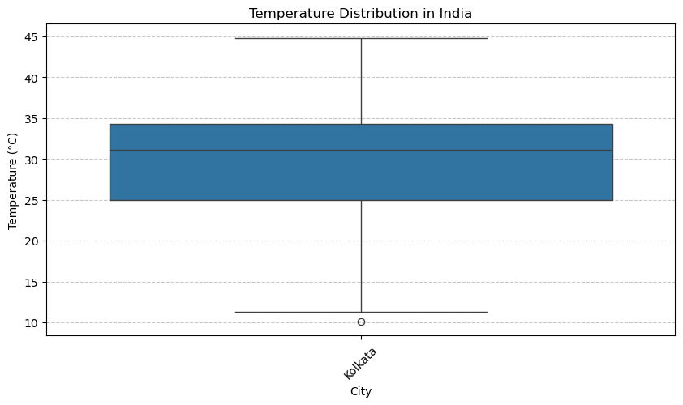

```python
india_df = df[df['country'] == 'India']
plt.figure(figsize=(10,5))
sns.boxplot(x='city', y='temperature_celsius', data=india_df)
plt.title("Temperature Distribution in India")
plt.xlabel("City")
plt.ylabel("Temperature (°C)")
plt.xticks(rotation=45)
plt.grid(axis='y', linestyle='--', alpha=0.7)

plt.show()
```

# year_Wise PM 2.5

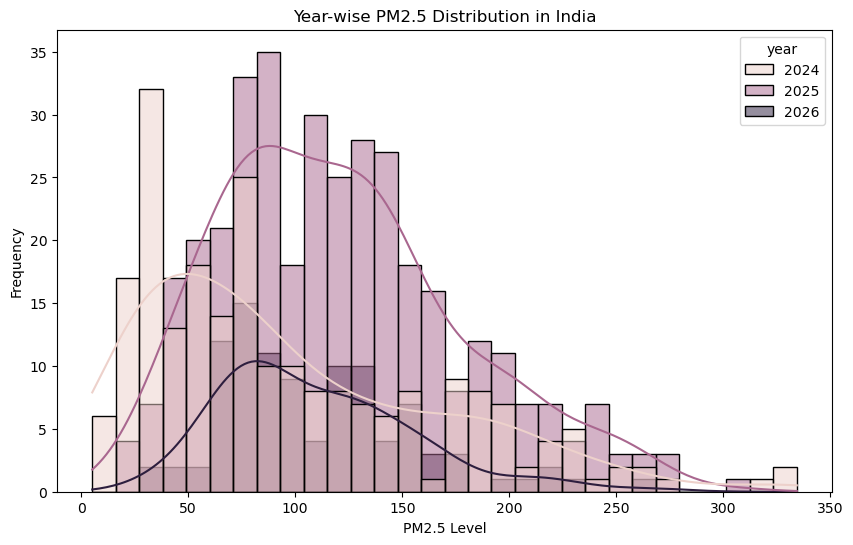

```python
india_df = df[df['country'] == 'India']

plt.figure(figsize=(10,6))
sns.histplot(data=india_df,
             x='air_quality_PM2.5',
             hue='year',
             bins=30,
             kde=True)

plt.title("Year-wise PM2.5 Distribution in India")
plt.xlabel("PM2.5 Level")
plt.ylabel("Frequency")

plt.show()
```

##### .Shows distribution of PM2.5 levels in India for each year

##### .Different colors represent different years

Helps compare how air pollution changed over time

Peaks indicate most common PM2.5 ranges

KDE curve shows overall trend (smooth distribution)

Useful to identify years with higher pollution concentration

## PM 2.5 2025

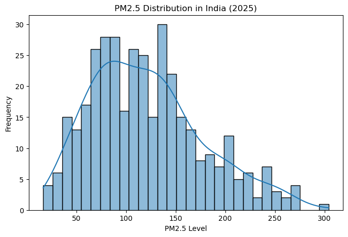

```python
india_2025 = df[(df['country'] == 'India') & (df['year'] == 2025)]

plt.figure(figsize=(8,5))

sns.histplot(india_2025['air_quality_PM2.5'], bins=30, kde=True)

plt.title("PM2.5 Distribution in India (2025)")
plt.xlabel("PM2.5 Level")
plt.ylabel("Frequency")

plt.show()
```

### * Displays the distribution of PM2.5 levels in India for 2025

- Shows how frequently different pollution levels occur
- Peak bars indicate the most common PM2.5 range
- KDE curve gives a smooth view of overall trend
- Helps identify whether pollution is mostly low, moderate, or high in 2025
- Useful for understanding air quality pattern in that year

# Weather Condition Distribution in India

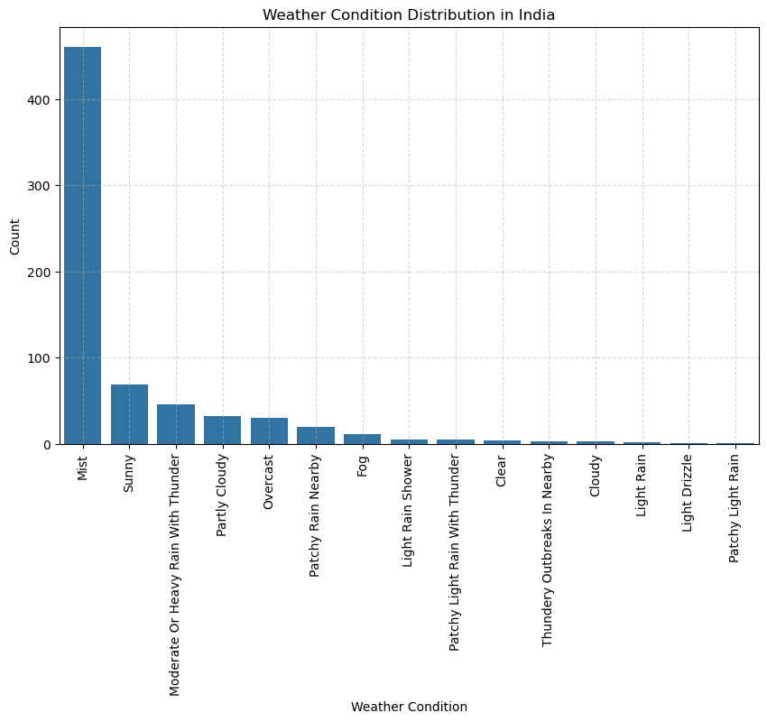

```python
india_data = df[df['country'] == 'India']
condition_counts = india_data['condition_text'].value_counts().reset_index()
condition_counts.columns = ['condition_text', 'count']
plt.figure(figsize=(10,6))
sns.barplot(x='condition_text', y='count', data=condition_counts)
plt.title("Weather Condition Distribution in India")
plt.xlabel("Weather Condition")
plt.ylabel("Count")
plt.xticks(rotation=90)
plt.grid(True, linestyle='--', alpha=0.5)
plt.show()
```

##### * Shows different weather conditions in India and their frequency

- Bars represent how often each condition (e.g., Sunny, Cloudy, Rainy) occurs
- Helps identify the most common weather condition
- Taller bars = more frequent conditions
- Useful to understand overall weather pattern distribution in India
- Rotation of labels improves readability for multiple conditions

## Relationship Between Temperature And Humidity

```python
gf=df.loc[:10]
```

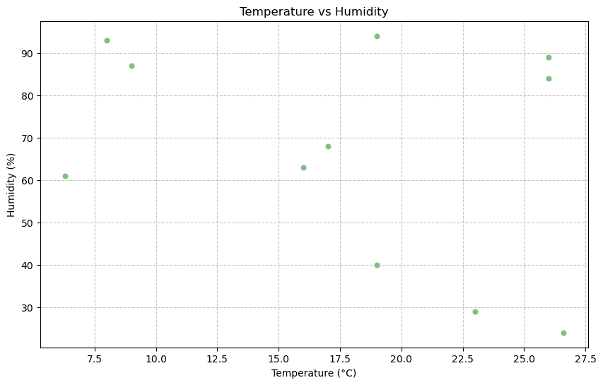

```python
plt.figure(figsize=(10,6))

sns.scatterplot(
    x='temperature_celsius',
    y='humidity',
    data=gf,
    color='Green',
    alpha=0.5

)

plt.title("Temperature vs Humidity")
plt.xlabel("Temperature (°C)")
plt.ylabel("Humidity (%)")
plt.grid(True, linestyle='--', alpha=0.7,)

plt.show()
```

##### This scatter plot shows the relationship between temperature and humidity. It helps identify patterns and variation between the two variables.

# Wind Speed Distribution

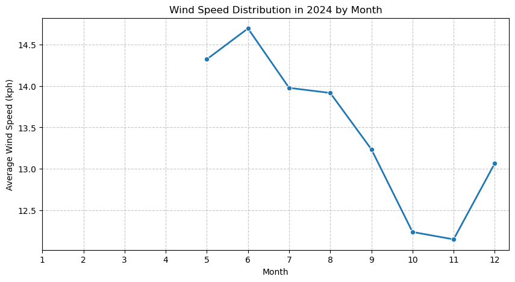

```python
df_2024 = df[df['year'] == 2024]
monthly_wind = df_2024.groupby('month')['wind_kph'].mean().reset_index()
plt.figure(figsize=(10,5))
sns.lineplot(x='month', y='wind_kph', data=monthly_wind, marker='o', linewidth=2)
plt.title("Wind Speed Distribution in 2024 by Month")
plt.xlabel("Month")
plt.ylabel("Average Wind Speed (kph)")
plt.xticks(range(1,13))
plt.grid(True, linestyle='--', alpha=0.7)

plt.show()
```

##### This chart shows the monthly average wind speed distribution in 2024. It helps compare wind speed changes across different months.

## Correlation Graph

### Correlation Heatmap Of Environmental Factors

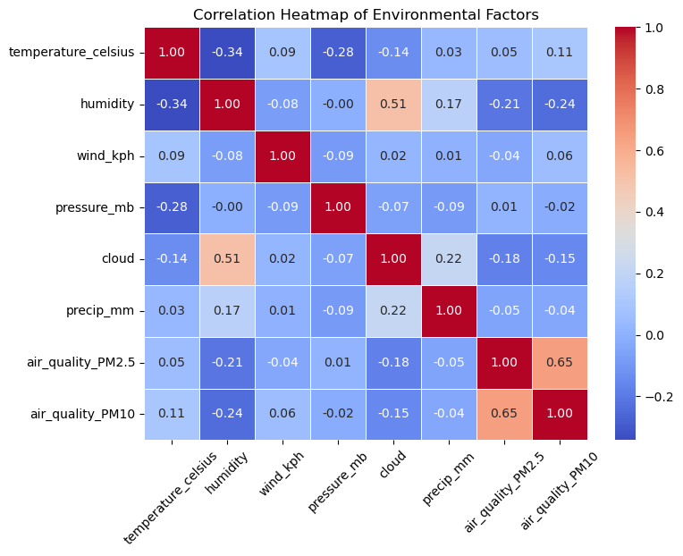

```python
import matplotlib.pyplot as plt
import seaborn as sns
env_data = df[['temperature_celsius', 'humidity', 'wind_kph',
               'pressure_mb', 'cloud', 'precip_mm',
               'air_quality_PM2.5', 'air_quality_PM10']]
corr_matrix = env_data.corr()
plt.figure(figsize=(8,6))
sns.heatmap(corr_matrix, annot=True, cmap='coolwarm', fmt='.2f', linewidths=0.5)
plt.title("Correlation Heatmap of Environmental Factors")
plt.xticks(rotation=45)
plt.yticks(rotation=0)
plt.show()
```

##### This heatmap shows the correlation between environmental factors such as temperature, humidity, wind speed, pressure, rainfall, cloud cover, and air pollution. It helps identify positive and negative relationships between variables.

### 27/4/2026 (Day 7)

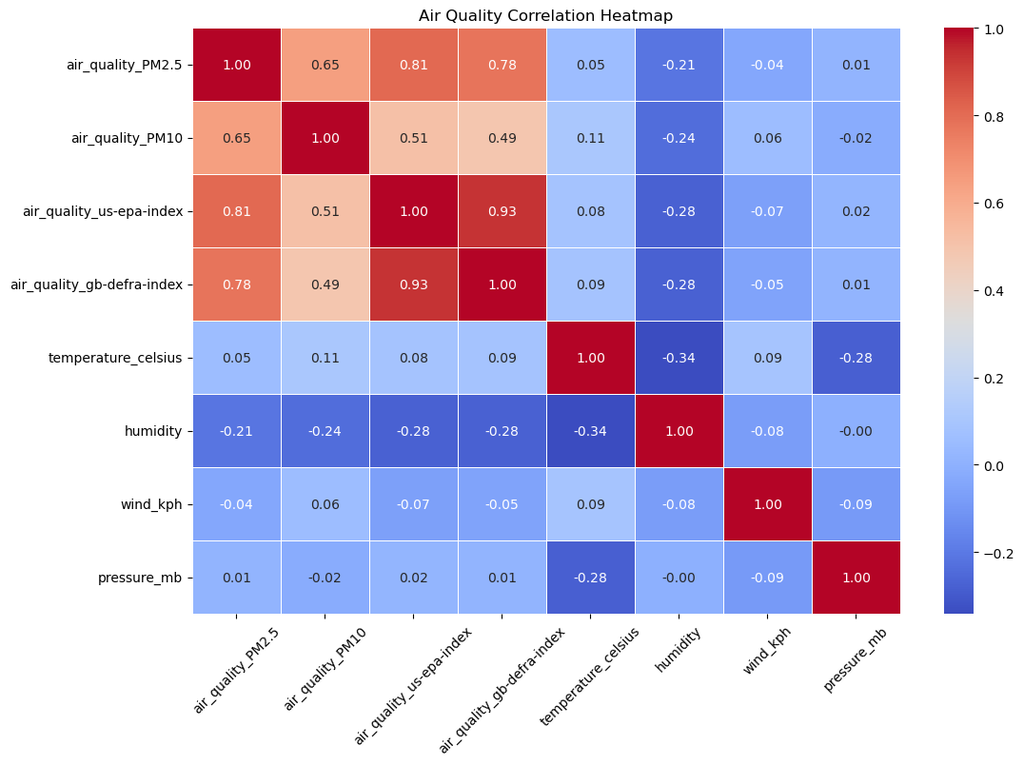

```python
air_data = df[['air_quality_PM2.5',
               'air_quality_PM10',
               'air_quality_us-epa-index',
               'air_quality_gb-defra-index',
               'temperature_celsius',
               'humidity',
               'wind_kph',
               'pressure_mb']]
corr_matrix = air_data.corr()
plt.figure(figsize=(12,8))
sns.heatmap(corr_matrix,
            annot=True,
            cmap='coolwarm',
            linewidths=0.5,
            fmt='.2f')

plt.title("Air Quality Correlation Heatmap")
plt.xticks(rotation=45)
plt.yticks(rotation=0)
plt.show()
```

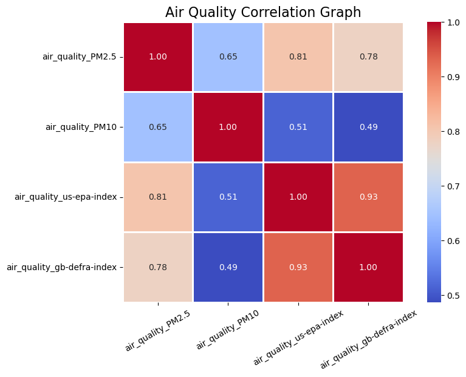

```python
import matplotlib.pyplot as plt
import seaborn as sns
air_quality = df[['air_quality_PM2.5',
                  'air_quality_PM10',
                  'air_quality_us-epa-index',
                  'air_quality_gb-defra-index']]
corr = air_quality.corr()
plt.figure(figsize=(10,6))

sns.heatmap(corr,
            annot=True,
            cmap='coolwarm',
            linewidths=1,
            fmt='.2f',
            square=True)

plt.title("Air Quality Correlation Graph", fontsize=16)
plt.xticks(rotation=30)
plt.yticks(rotation=0)

plt.show()
```

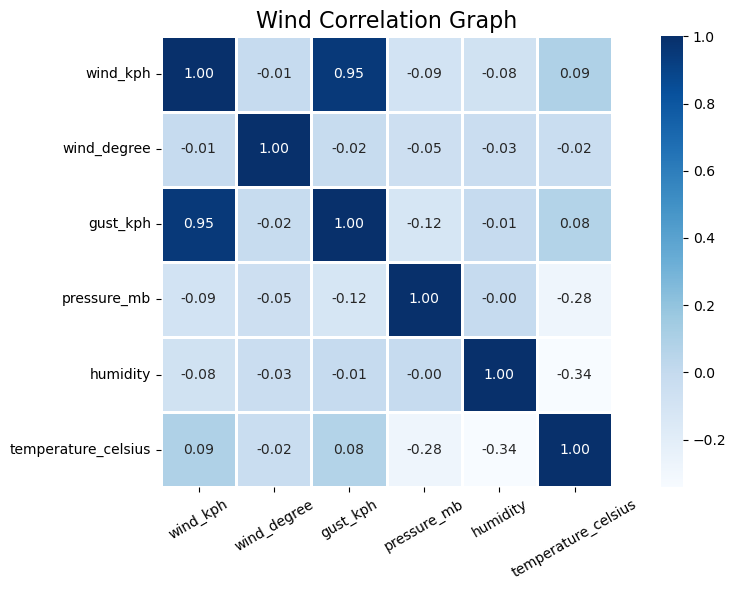

```python
wind_data = df[['wind_kph',
                'wind_degree',
                'gust_kph',
                'pressure_mb',
                'humidity',
                'temperature_celsius']]

corr = wind_data.corr()

plt.figure(figsize=(10,6))

sns.heatmap(corr,
            annot=True,
            cmap='Blues',
            linewidths=1,
            fmt='.2f',
            square=True)

plt.title("Wind Correlation Graph", fontsize=16)
plt.xticks(rotation=30)
plt.yticks(rotation=0)

plt.tight_layout()
plt.show()
```

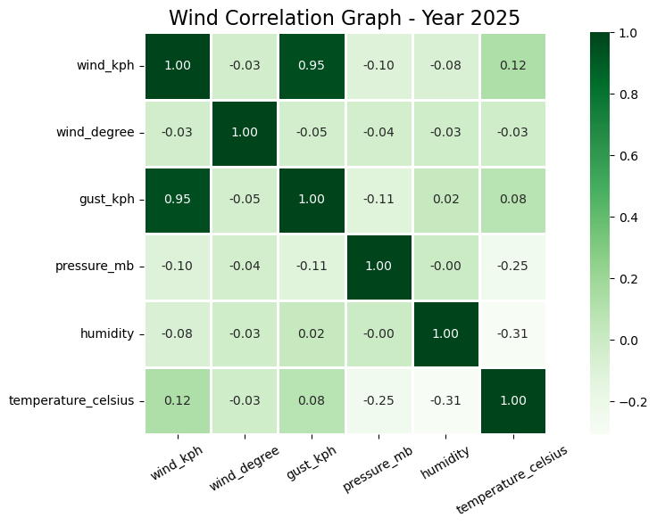

```python
df_2025 = df[df['year'] == 2025]
wind_data = df_2025[['wind_kph',
                     'wind_degree',
                     'gust_kph',
                     'pressure_mb',
                     'humidity',
                     'temperature_celsius']]
corr = wind_data.corr()
plt.figure(figsize=(10,6))

sns.heatmap(corr,
            annot=True,
            cmap='Greens',
            linewidths=1,
            fmt='.2f',
            square=True)
plt.title("Wind Correlation Graph - Year 2025", fontsize=16)
plt.xticks(rotation=30)
plt.yticks(rotation=0)
plt.tight_layout()
plt.show()
```

## Global Average Temperature By Year

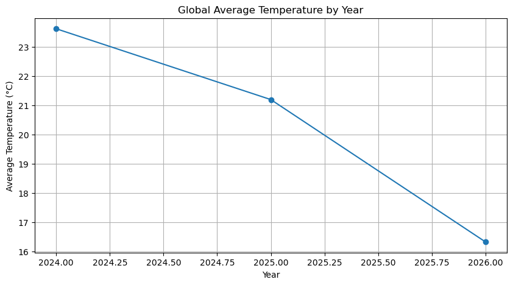

```python
df.columns = df.columns.str.strip()
yearly_temp = df.groupby('year')['temperature_celsius'].mean()
plt.figure(figsize=(10,5))
plt.plot(yearly_temp.index, yearly_temp.values, marker='o')
plt.xlabel('Year')
plt.ylabel('Average Temperature (°C)')
plt.title('Global Average Temperature by Year')
plt.grid(True)
plt.show()
```

- Displays the year-wise average global temperature
- Each point represents the mean temperature of that year
- Line shows the trend over time (increase or decrease)
- Upward trend → rising temperatures (possible warming)
- Downward trend → decreasing temperatures
- Helps identify long-term climate patterns and changes

## Air Pollution Heatmap

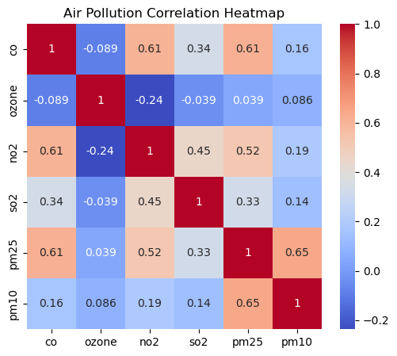

```python
pollution_df = df[['co', 'ozone', 'no2', 'so2', 'pm25', 'pm10']]

corr = pollution_df.corr()

plt.figure(figsize=(6,5))
sns.heatmap(corr, annot=True, cmap='coolwarm')

plt.title("Air Pollution Correlation Heatmap")
plt.show()
```

# pair Plot

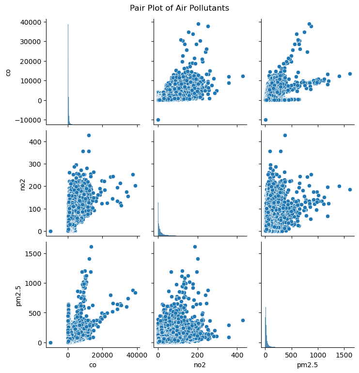

```python
pollution_df = df[['co', 'no2',  'pm2.5', ]]

# Pair plot
sns.pairplot(pollution_df)

plt.suptitle("Pair Plot of Air Pollutants", y=1.02)
plt.show()
```

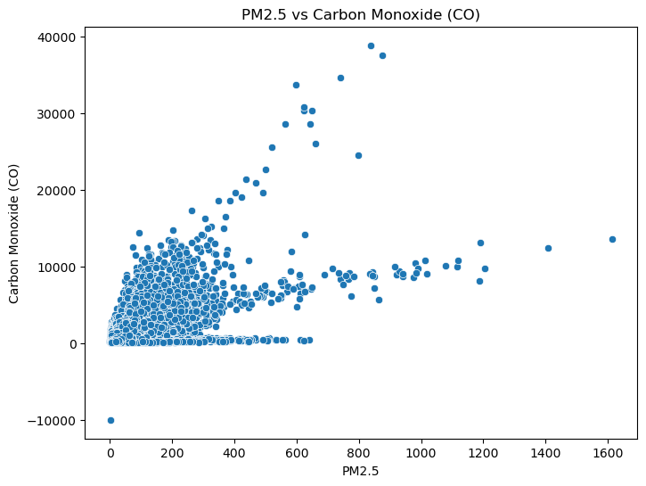

```python
plt.figure(figsize=(8,6))

sns.scatterplot(x='air_quality_PM2.5',
                y='air_quality_Carbon_Monoxide',
                data=df)

plt.title("PM2.5 vs Carbon Monoxide (CO)")
plt.xlabel("PM2.5")
plt.ylabel("Carbon Monoxide (CO)")

plt.show()
```

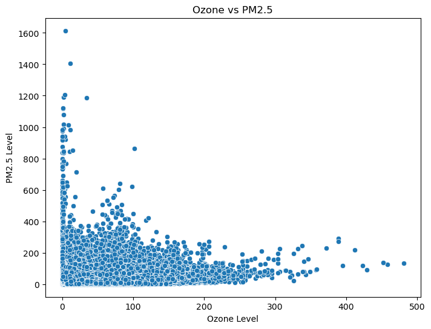

```python
plt.figure(figsize=(8,6))

sns.scatterplot(x='air_quality_Ozone',
                y='air_quality_PM2.5',
                data=df)

plt.title("Ozone vs PM2.5")
plt.xlabel("Ozone Level")
plt.ylabel("PM2.5 Level")

plt.show()
```

Points spread → weak relation Pattern/line → strong relation

## Pair PLot Of Air Pollutants

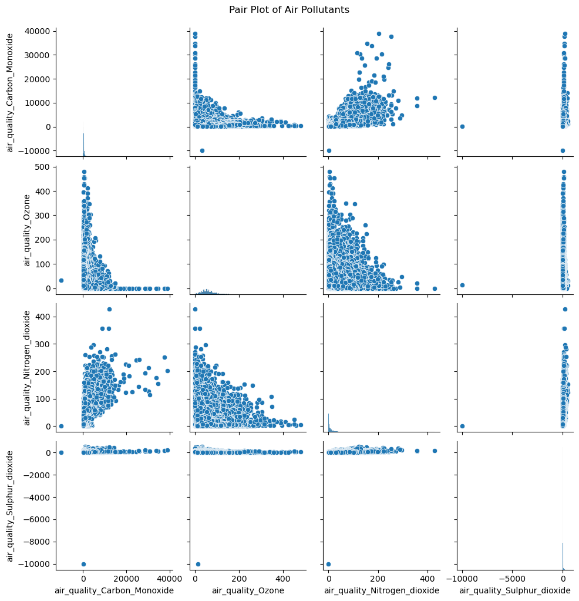

```python
pollution_df = df[['air_quality_Carbon_Monoxide',
                   'air_quality_Ozone',
                   'air_quality_Nitrogen_dioxide',
                   'air_quality_Sulphur_dioxide']]

sns.pairplot(pollution_df)

plt.suptitle("Pair Plot of Air Pollutants", y=1.02)
plt.show()
```

## co VS PM 2.5

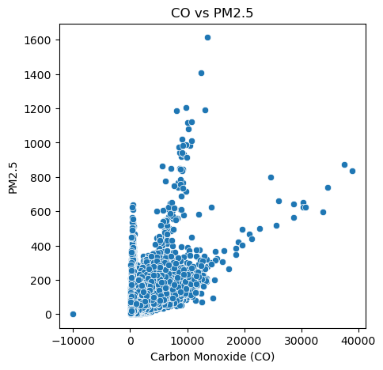

```python
plt.figure(figsize=(5,5))

sns.scatterplot(x='co', y='pm2.5', data=df)

plt.title("CO vs PM2.5")
plt.xlabel("Carbon Monoxide (CO)")
plt.ylabel("PM2.5")

plt.show()
```

#### Shows relationship between CO and PM2.5 levels

If points follow an upward trend → positive correlation

Scattered points → weak or no strong relationship

High values together indicate pollution peaks

Helps understand if both pollutants come from similar sources

## CO VS NO2

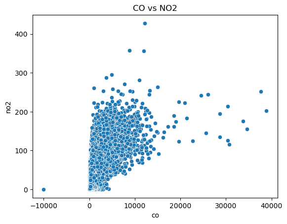

```python
sns.scatterplot(x='co', y='no2', data=df)

plt.title("CO vs NO2")
plt.show()
```

#### Shows relationship between CO and NO₂ levels

Upward pattern → positive correlation

Scattered points → weak relationship

High values together indicate pollution spikes

Suggests both may come from vehicle/industrial emissions